# FinalPaper_group8

## Impact of the COVID-19 pandemic on the number of flights in Italy

1. Group member and contribution statement
2. Introduction
3. Main research question and sub-research questions
4. Research methods
5. Data collection
6. Results
7. Discussion
8. Conclusion
9. References
10. Appendix

# 1. Group member and contribution statement

**Members:**

Daan van der Klooster  
Iardena Kuznetch  
Thom Gietelink  
Thomas Dušić

**Studentnumbers:**

4553675 / 5850193 / 4478207 / 4608763

**Contribution statement:**

Daan van der Klooster: text on chapters 4 and 5, coding and plotting figures 1, 2, 3, 4, extraction of available data on air traffic (first appendix), improvement of readabiltiy/adjustments of figures, implementation of Mid-Term feedback on own and other works

Iardena Kuznetch: Answer question 1B to 1E, work on the conclusions, Add appendix for the question 1, work on the introduction, add images for the results, coding and plotting figure 2, 6, 8

Thom Gietelink: introduction, answer question 3 and 4, extraction of available data on COVID-cases, addition of appendices, coding and plotting figure 3, 7, 10, 11, implementation of Mid-Term feedback on own and other works

Thomas Dušić: discussion, answer questions 1A and 1E, coding and plotting figure 3, 5, 9, 12, 13

## 2. Introduction

In 2020, a new event happend which changed everyones lives. A small virus which originated from China and made sure that everyone needed to tread with cautioun. So no country was safe. In the Nehterlands, it was top priority to make sure it would disapear as quickly as possible. To quote the prime minister of the Netherlands, Mark Rutte: ''The coronavirus affects us all. We are going through a difficult time and it will remain so for some time to come. Persistence becomes more difficult. That is why it is important that we look after each other even more. That we help each other where we can''. To the suprise of no one, the transport sector was hit hard due to countries deciding to close their borders.

Countries that were probably hit hardest, were the countries which are dependent on tourism. This was the case for countries like Spain, Italy and Greece. This meant that the transport sector was hit hard due to the fact that there were no tourists. For this paper, only Italy will be looked into. The virus made sure that the transport sector had to adapt to the new situation. Because of the relevance of COVID-19, this paper will look at the impact of COVID-19 on the transport sector in Italy, in particular air transportation.

## 3. Main research question and sub-research questions

**Research Objective**

Did the COVID-19 breakout in Italy affect air travel towards Italy's five main airports during the month of July in 2020 and 2021, in comparison to July 2019?

**Sub-questions**

1. What impact of COVID-19 can be seen on the number of flights in 2021, in comparisson to both 2019 and 2020.

   A. How many flights arrived on the airports during July of 2019, 2020, 2021?

   B. How many COVID-cases were there in Italy in 2020 and 2021?

   C. What impact of COVID-19 can be seen on the number of flights in 2020 and 2021, in comparisson to 2019.

   D. What impact of mortality can be seen on the number of flights in 2020 and 2021?

   E. Is there a difference in flight arrivals visible (when it comes to percentual increase or decrease) in between the five airports (taking all three years into account)?
2. How do the number of vaccinations impact the number of flights in 2021? A. Is there a clear correlation between the vaccination rate in 2021 and the number of COVID-cases?
3. Was there an ascending or decreasing trent in COVID-cases just before the start of July (in both 2020 and 2021)?

## 4. Research methods

To answer the main research question the sub-questions will be answered which are important due to the what was explained in the previous part.

These questions will be answered by using data analysis and data visualization, with the help of python and the libraries pandas, numpy, matplotlib and seaborn to find correlations between the number of flights and the number of COVID-cases. If there is a correlation, it will be tried to find out what the cause of this correlation is, based on both even more analysis of available data and logical thinking. This is the best way to answer the main research question because of the abundance of data that is available.

Data on both air traffic in Italy and the COVID-19 situation in this country has been achieved from different reliable data sources. This will be elaborated on in the next chapter.

At first, hard numbers will have to be achieved in order to find correlations. This means that firstly, all the relevant data has to be extracted from the huge available databeses. This includes the number of flights arriving to Italy's five main airports, as well as all number related to COVID-19 for this country. One can think of cases, number of performed COVID-tests and number of vaccinations. It will be absolutely necessary to extract the correct and relevant data first, as databases are used that contain information on a global level, not a national level. This means that it can be said that the extraction of data will be necessary in order to ensure both relevancy and workability. It is chosen only to use flights towards the five airports (so not departing from the airports). Furthermore, for all years, only the seventh month of the year, July, will be taken into account.

Note that the interpretation of the results will be performed, based on the two main data sources only. Later on, it will be further discussed that potential, external influences are left out of the research. This choice was made, mainly because of the scarcity of complete and relevant datasources, as well as the time and main purpose that is set for this report.

Visialisation will be the most important way that is used of clarifying the results. Due to the great amount of data, it will nearly be impossible to compare data and results without visualisation. This way, results can be made perfectly clear within one eyecatch. In addition, verbal explanation and interpretation will be provided, in order to receive a complete overview.

At last, with the comparison of data through visiualisation, it will not only be possible to interpret all results, it will also be possible to search for correlations or possible causes. This will be done, usually based on logical thinking. This means that the whole process will be performed once again, this time taking into account different kind of data. Using visualisation once again, it will hopefully be possible to validate the expectations of correlation. If so, conclusions can be made and the main research question can be answered.

Note that the process as described previously, also lies within the formulation and order of the sub-questions that were also provided.

## 5. Data collection

In the first stage of this research, it is necessary to find data that is both relevant and reliable for answering all sub-questions and the main research question. The required data can roughly be split into two types:

- Data on air traffic towards Italy's five main airports
- Relevant data on COVID-19 in Italy (number of cases, number of vaccinations)

In order to be able to compare results, data must be organisable by one other criterion, preferrably time. Also preferably, the same scale for both datasets will be used.

For information on air traffic, Flight Route Database was consulted. This database contains quite a lot of data: available data on aviation on a global scale is provided in this dataset, for every day, 24/7. Available data can include the airport the plane departed from, the airport where it landed, time of departure, time of arrival, type of aircraft, etc. This dataset will be greatly usefull as data source for this research, at it contains all information on flights towards the airports that are included in this research for on a very small time scale. Using coding, it will later on be possible to alter this scale to a bigger one, for example daily or simply the total number of the month. Once the data set is in place, it will be possible to extract all information that is necessary: all flights with one of the five main Italian airports as destination, within the month of July in 2019, 2020 and 2021.

In order to extract all relevant information on COVID-19 data, a different database is used. This database is called Coronavirus Source Data, and it included all data related to COVID-19 (number of cases, vaccinations, deaths) that were confirmed by the official govornmental institutions of each country worldwide, for each day since the beginning of the pandemic. This database can be very usefull, as it includes all confirmed cases and vaccinations set in Italy throughout a very long period (starting at the beginning of 2020) on a daily scale. This scale is very handy, as it is always possible to enlarge this scale to monthly or yearly. Decreasing of scale on the other hand will be extremely difficult to do accurately.

These two databases will be used in order to visualise al numbers and compare results. The appendices of this report contain multiple cells of coding that was used in order to extract all relevant data from the enormous databases.

## 6. Results

In this chapter, the result/visualisation of all stated subquestions can be found

```python
from IPython.display import Image
```

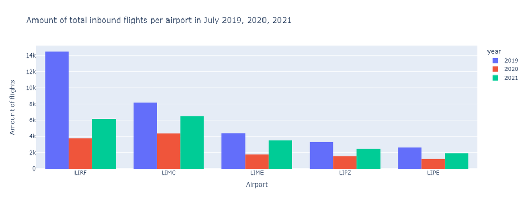

```python
# Load image Totaal inbound flights per airports.png and display them in the notebook

Image(filename='Totaal inbound flights per airports.png')
```

Figure 1

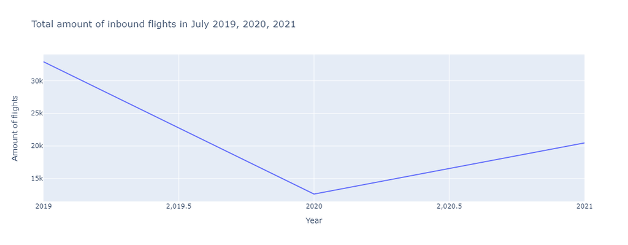

```python
# Load Incremental growth of all the airports.png and display them in the notebook

Image(filename='Question 1 Incremental growth of all the airports.png')
```

Figure 2

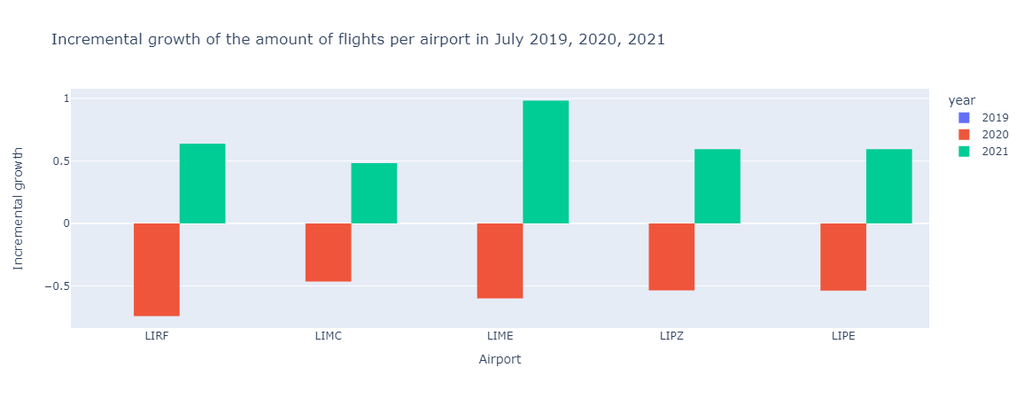

```python
# Load image Question 1 Incremental growth on flights per airport.png and display them in the notebook

Image(filename='Question 1 Incremental growth on flights per airport.png')
```

Figure 3

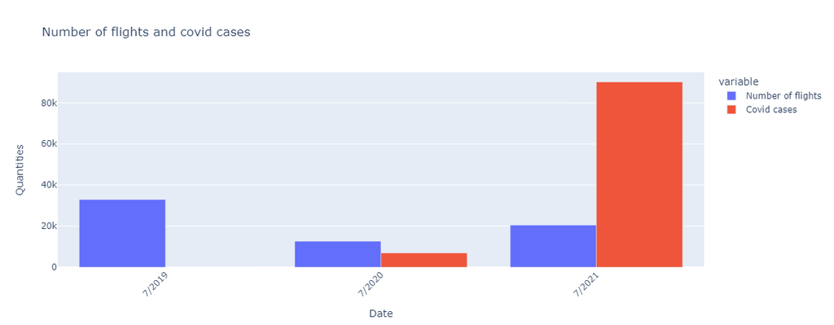

```python
# Load Covid cases month seven each year

Image(filename='Question 1 flights-covidcases.png')
```

Figure 4

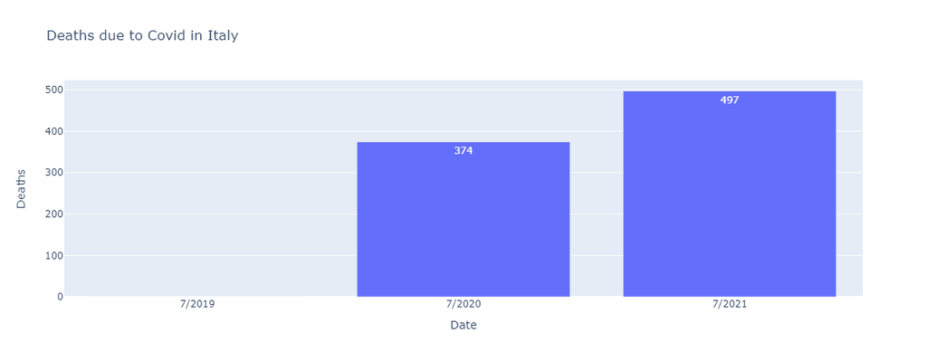

```python
# Load Question 1 question 1 deaths.png and display them in the notebook

Image(filename='question 1 deaths.png')
```

Figure 5

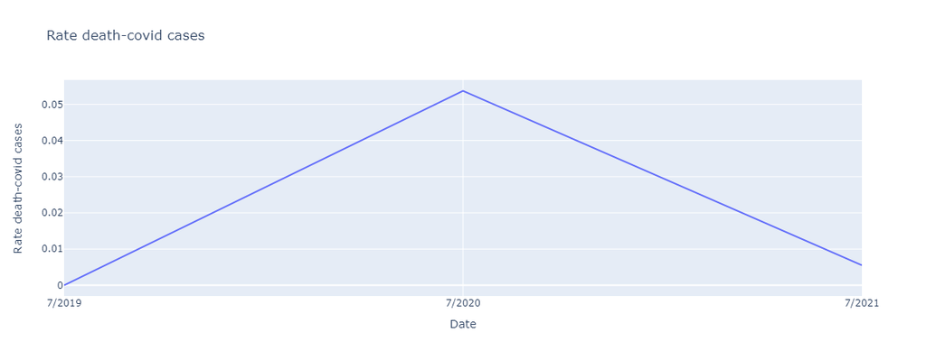

```python
# Load Question 1 rate death covid cases.png and display them in the notebook

Image(filename='Question 1 rate death covid cases.png')
```

Figure 6

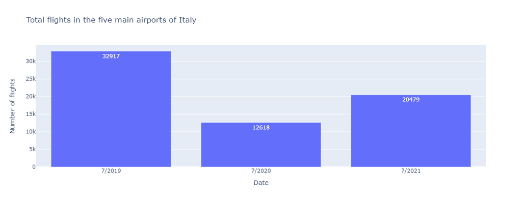

```python
# Load Question 1 Totalflightspermonth7.png and display them in the notebook

Image(filename='Question 1 Totalflightspermonth7.png')
```

Figure 7

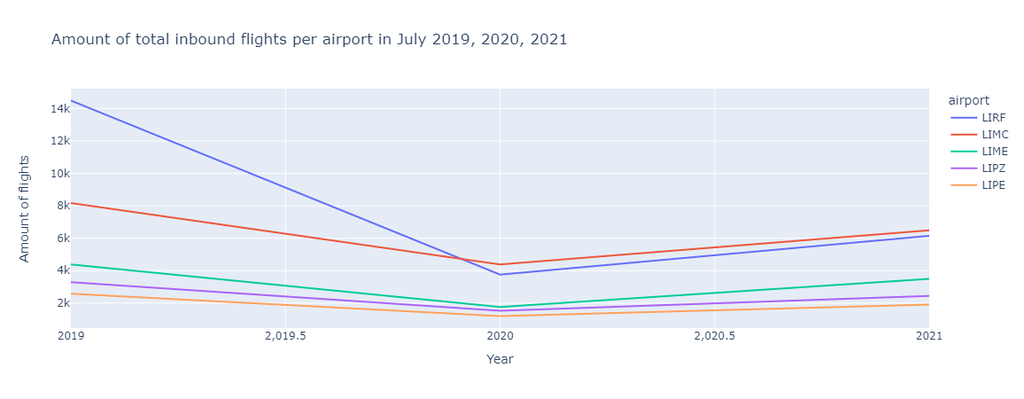

```python
# Load Question 1 Lineplot flights per year.png and display them in the notebook

Image(filename='Question 1 Lineplot flights per year.png')
```

Figure 8

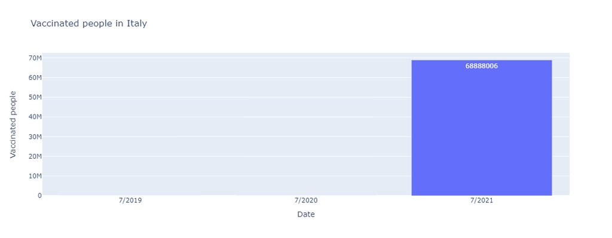

```python
# Load Question 1 vaccination.png and display them in the notebook

Image(filename='Question 1 vaccination.png')
```

Figure 9

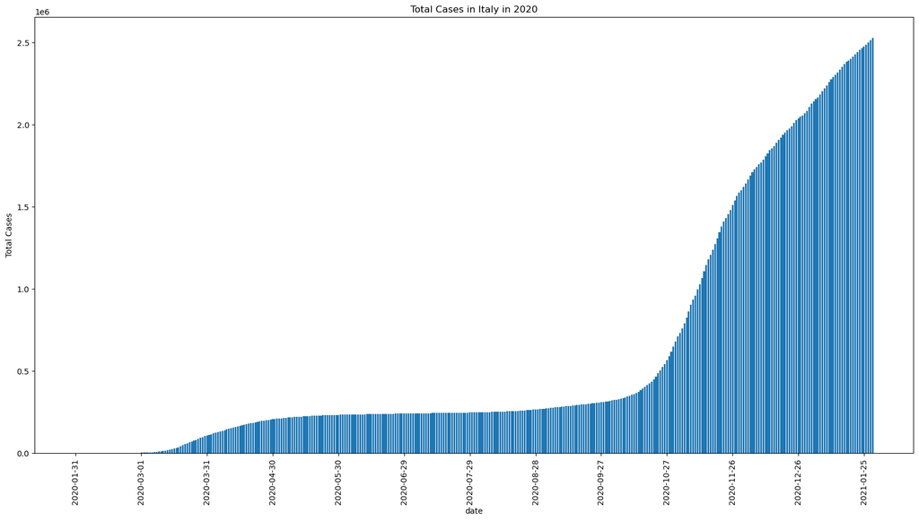

```python
# Load images Total Cases in Italy in 2020.png and display them in the notebook


Image(filename='Total Cases in Italy in the year 2020.png')
```

Figure 10

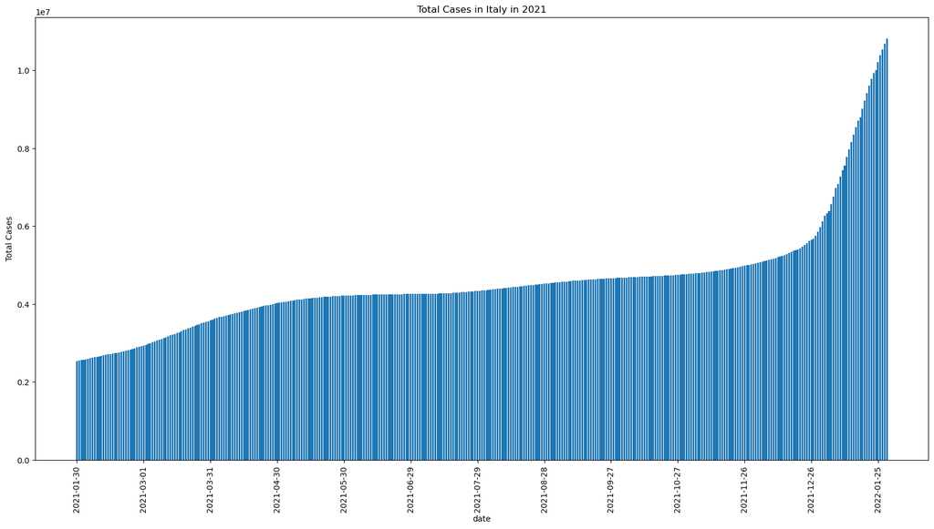

```python
# Load images Total Cases in Italy in 2021.png and display them in the notebook

Image(filename='Total Cases in Italy in 2021.png')
```

Figure 11

[figure not shown]

```python
# Load images Total Cases in Italy in 07/2020 and display them in the notebook

Image(filename='Question 3 ascendingJuly2020.png')
```

Figure 12

[figure not shown]

```python
# Load images Total Cases in Italy in 07/2021 and display them in the notebook

Image(filename='Question 3 ascendingJuly2021.png')
```

Figure 13

## 7. Discussion

1. What impact of COVID-19 can be seen on the number of flights in 2021, in comparisson to both 2019 and 2020?

   A. How many flights arrived on the airports during July of 2019, 2020, 2021?

   B. How many COVID-cases were there in Italy in 2020 and in 2021?

   C. What impact of COVID-19 can be seen on the number of flights in 2020, in comparison to 2019?

   It is clearly visible that there is a huge decline in the amount of inbound flights in the airports. Per airport, it is the decline is significant when comparing the inbound flight numbers to each other. In most the airports the number of flights is less then half of what it was in 2019

   D. What impact of mortality can be seen on the number of flights in 2020 and 2021?

   An interesting thing about the data is that the amount of deaths due to COVID-19 and the amount of flights doesn't correlate in a matter that someone would assume. The amount of COVID-19 related deaths in Italy is actually higher in 2021 than in 2020. Yet there were more flights in 2021 than in 2020. An explanation for this could be that the effects ofcovid-19 were not know that well in 2020 therefore the restriction were harder.

   E. Is there a difference in flight arrivals visible (when it comes to percentual increase or decrease) in between the five airports (taking all three years into account)?

   When looking ath the incremental growth result it is visible that there for the year 2020 there is a huge percentual decrease when comparing the data to 2019. This value is around -0.61 meaning that there is a 61 percent decrease. When comparing 2020 and 2021 there is a significant increase in the amount of flights for the airports. This is a percentual increase of 0.62, so this is an increase of 62 percent.
2. How do the number of vaccinations impact the number of flights in 2020 and 2021

1. Was there an ascending or decreasing trend in COVID-cases just before the start of July (in both 2020 and 2021)?

The trend for 2020 and as well for 2021 was that there was a steady number of people getting COVID-19. There is a slight increase of the number of COVID-19 cases, but it is minimal.

## 8. Conclusion

1. What is the answer to the main research question:

Did the COVID-19 breakout in Italy affect air travel towards Italy's five main airports during the month of July in 2020 and 2021, in comparison to July 2019?

1. What are the answers to the sub-research questions:

What impact of COVID-19 can be seen on the number of flights in 2021, in comparisson to both 2019 and 2020.

A. How many flights arrived on the airports during July of 2019, 2020, 2021?

During July 2019 the total number of flights arriving to the airports was 32917, then it was 12618 during 2020, and 20479 during 2021.

B. How many COVID-cases were there in Italy in 2020 and 2021?

C. What impact of COVID-19 can be seen on the number of flights in 2020 and 2021, in comparisson to 2019.

```
The number of flights decreased from 2019 to 2020 due to the impact of covid. Then in 2021 it recovered partially.
```

D. What impact of mortality can be seen on the number of flights in 2020 and 2021?

While in July 2020 the numver of deaths was 374, during 2021 it was 497. If we relate it to the number of new cases for the same periods, it is noticeable that the mortality was lower in 2021 than in 2020, and that explains the recovery.

E. Is there a difference in flight arrivals visible (when it comes to percentual increase or decrease) in between the five airports (taking all three years into account)?

It is observed that all the number of flights decreased in all the airports during 2020, and then recovered partially in 2021.

How do the number of vaccinations impact the number of flights in 2021? A. Is there a clear correlation between the vaccination rate in 2021 and the number of COVID-cases?

Was there an ascending or decreasing trent in COVID-cases just before the start of July (in both 2020 and 2021)?

1. Limitations

The usage of statistical data has some limitations. There can be effects on the data, for example socioeconomical effects, or environmental effects that are not considered while making assumptions about the data. Even tough there is a correlation between the data obtained, there are still side effects that can affect it. The Covid data used is not distinguished between cities of Italy, but just the entire country, assuming that the difference between cities regarding the effect of Covid was not considerable huge. That assumption was based in that we took the main airports, which mean the main cities of Italy, and Covid spreaded faster in high density populated places.

1. Recommendations

To deep into the topic it is advisable to extend the study to entire continents, or analyze more countries. In addition, to know more of the effect of covid, it is adviceable to take into account entire year periods to get to know more of the effect of covid given other major factors like low temperatures. Another possible extension of the analysis is to take into account small towns to understand how it affected high or low population cities.

## 9. References

1. Mathieu, E. (2020, March 5). Coronavirus Source Data. Our World in Data. https://ourworldindata.org/coronavirus-source-data conculted on 2022-10-10
2. Flight Route Database. (2017, August 29). Kaggle. https://www.kaggle.com/open-flights/flight-route-database conculted on 2022-10-10

## 10. Appendix

The code to seperate the covid data found at https://ourworldindata.org/coronavirus-source-data.

```python
# Appendix 1: covid data, download from https://ourworldindata.org/coronavirus-source-data, can't be uploaded to github due to size limit

'''import owid_covid_data.csv'''

import pandas as pd
import numpy as np
import matplotlib.pyplot as plt
import seaborn as sns
import plotly.express as px
from cgitb import text


# Read the data
#df = pd.read_csv('owid_covid_data.csv')

# Check the data
#df.head()

#'''all data from Italy must be in a separate dataframe'''

# Create a new dataframe with only Italy data
#df_italy = df[df['location'] == 'Italy']


#'''filter collumns from df_italy except date, total_cases, new_cases, total_deaths, new_deaths,total_cases_per_million, new_cases_per_million, total_deaths_per_million, new_deaths_per_million, total_vaccinations, people_fully_vaccinated_per_hundred, new_vaccinations_smoothed_per_million'''

#df_italy = df_italy[['date', 'total_cases', 'new_cases', 'total_deaths', 'new_deaths', 'total_cases_per_million', 'new_cases_per_million', 'total_deaths_per_million', 'new_deaths_per_million', 'total_vaccinations', 'people_fully_vaccinated_per_hundred','new_vaccinations_smoothed_per_million']]
#print(df_italy.head())

#'''visualize the df_italy data by plotting a line graph with date being the x-axis and new_cases_per_million being the y-axis'''

# Plot the data
#plt.figure(figsize=(20,10))
#plt.plot(df_italy['date'], df_italy['new_cases_per_million'])
#plt.xlabel('Date')
#plt.ylabel('New Cases Per Million')
#plt.title('New Cases Per Million in Italy')
#plt.show()

# show dimensions of the df_italy dataframe
#print(df_italy.shape)

# show last 5 dates of data in df_italy
#print(df_italy.tail())
```

As the data files of the three years consists of an incredible amount of data, it was chosen to not use the full datasets, but to split these up and filter out the required data only. In order to avoid having to upload all the complete datafiles (due to their enormous size), all code is put behind hashtags.

```python
# appendix 2: Flight data, download from https://www.kaggle.com/open-flights/flight-route-database, can't be uploaded to github due to size limit

# Get 2019, 2020 and 2021 data of worldwide flights during the month of July ""
# data2019 = pd.read_csv("flightlist_20190701_20190731.csv")
# data2020 = pd.read_csv("flightlist_20200701_20200731.csv")
# data2021 = pd.read_csv("flightlist_20210701_20210731.csv")

# Filtering the data to obtain each destination airport separately

# Year 2019
# dataROME2019 = data2019[data2019['destination'] == 'LIRF']
# dataMILAN2019 = data2019[data2019['destination'] == 'LIMC']
# dataVENICE2019 = data2019[data2019['destination'] == 'LIPZ']
# dataBOLOGNA2019 = data2019[data2019['destination'] == 'LIPE']
# dataBERGAMO2019 = data2019[data2019['destination'] == 'LIME']

# Year 2020
# dataROME2020 = data2020[data2020['destination'] == 'LIRF']
# dataMILAN2020 = data2020[data2020['destination'] == 'LIMC']
# dataVENICE2020 = data2020[data2020['destination'] == 'LIPZ']
# dataBOLOGNA2020 = data2020[data2020['destination'] == 'LIPE']
# dataBERGAMO2020 = data2020[data2020['destination'] == 'LIME']

# Year 2021
# dataROME2021 = data2021[data2021['destination'] == 'LIRF']
# dataMILAN2021 = data2021[data2021['destination'] == 'LIMC']
# dataVENICE2021 = data2021[data2021['destination'] == 'LIPZ']
# dataBOLOGNA2021 = data2021[data2021['destination'] == 'LIPE']
# dataBERGAMO2021 = data2021[data2021['destination'] == 'LIME']

# Creating a new .csv file for each airport destination and year

#Year 2019
# dataROME2019.to_csv('ROME2019.csv')
# dataMILAN2019.to_csv('MILAN2019.csv')
# dataVENICE2019.to_csv('VENICE2019.csv')
# dataBOLOGNA2019.to_csv('BOLOGNA2019.csv')
# dataBERGAMO2019.to_csv('BERGAMO2019.csv')

#Year 2020
# dataROME2020.to_csv('ROME2020.csv')
# dataMILAN2020.to_csv('MILAN2020.csv')
# dataVENICE2020.to_csv('VENICE2020.csv')
# dataBOLOGNA2020.to_csv('BOLOGNA2020.csv')
# dataBERGAMO2020.to_csv('BERGAMO2020.csv')

#Year 2021
# dataROME2021.to_csv('ROME2021.csv')
# dataMILAN2021.to_csv('MILAN2021.csv')
# dataVENICE2021.to_csv('VENICE2021.csv')
# dataBOLOGNA2021.to_csv('BOLOGNA2021.csv')
# dataBERGAMO2021.to_csv('BERGAMO2021.csv')
```

Filtering data to obtain smaller files

```python
#import the flight data from the italy in july 2019
#df = pd.read_csv('flightlist_20190701_20190731.csv', header=0, sep=',', quotechar='"')
#df.head()

#Filter the database so only the airports of interest are included
#df1 = df[(df['origin'] == 'LIME') | (df['origin'] == 'LIPZ') | (df['origin'] == 'LIPE') | (df['origin'] == 'LIRF')
#| (df['origin'] == 'LIMC') | (df['destination'] == 'LIME') | (df['destination'] == 'LIPZ')
#| (df['destination'] == 'LIPE') | (df['destination'] == 'LIRF') | (df['destination'] == 'LIMC')]
#df1.head(10)

#show the amount of inbounds and outbounds flights
#df1['origin'].value_counts()
#df1['destination'].value_counts()

#combine the amount of inbound and outbound flights per airport and create a new dataframe with inbound, outbound and total flights
#df2 = pd.concat([df1['origin'].value_counts(), df1['destination'].value_counts()], axis=1)
#df2.columns = ['origin', 'destination']
#df2['total'] = df2['origin'] + df2['destination']
#df2 = df2.sort_values(by='total', ascending=False)
#df2.head(5)

#add the month and the year to the dataframe and show this new dataframe
#df2['year'] = 2019
#df2['month'] = 7
#print(df2.head(5))


#save the shortend and filterd data to a new csv file, this csv file will be used in the last section to answer the subquestion
#df2.to_csv('flightlist_short_20190701_20190731.csv', header=True, sep=',', quotechar='"')
```

'''In the section below the same is done as in the section aboven but only for the year 2020 and the month of july. The data is filtered by the same criteria as in the section above.'''

```python
#import the csv file with the amount of flights per airport for july 2020
#df = pd.read_csv('flightlist_20200701_20200731.csv', header=0, sep=',', quotechar='"')
#df.head()

#Filter the database so only the airports of interest are included
#df1 = df[(df['origin'] == 'LIME') | (df['origin'] == 'LIPZ') | (df['origin'] == 'LIPE') | (df['origin'] == 'LIRF')
#| (df['origin'] == 'LIMC') | (df['destination'] == 'LIME') | (df['destination'] == 'LIPZ')
#| (df['destination'] == 'LIPE') | (df['destination'] == 'LIRF') | (df['destination'] == 'LIMC')]
#df1.head(10)

#show the amount of inbounds and outbounds flights
#df1['origin'].value_counts()
#df1['destination'].value_counts()

#combine the amount of inbound and outbound flights per airport and create a new dataframe with inbound, outbound and total flights
#df2 = pd.concat([df1['origin'].value_counts(), df1['destination'].value_counts()], axis=1)
#df2.columns = ['origin', 'destination']
#df2['total'] = df2['origin'] + df2['destination']
#df2 = df2.sort_values(by='total', ascending=False)
#df2.head(5)

#add the month and the year to the dataframe and show this new dataframe
#df2['year'] = 2020
#df2['month'] = 7
#print(df2.head(5))


#save the shortend and filterd data to a new csv file, this csv file will be used in the last section to answer the subquestion
#df2.to_csv('flightlist_short_20200701_20200731.csv', header=True, sep=',', quotechar='"')
```

'''In the section below the same is done as in the section aboven but only for the year 2021 and the month of july. The data is filtered by the same criteria as in the section above.'''

```python
#import the csv file with the amount of flights per airport for july 2021
#df = pd.read_csv('flightlist_20210701_20210731.csv', header=0, sep=',', quotechar='"')
#df.head()

#Filter the database so only the airports of interest are included
#df1 = df[(df['origin'] == 'LIME') | (df['origin'] == 'LIPZ') | (df['origin'] == 'LIPE') | (df['origin'] == 'LIRF')
#| (df['origin'] == 'LIMC') | (df['destination'] == 'LIME') | (df['destination'] == 'LIPZ')
#| (df['destination'] == 'LIPE') | (df['destination'] == 'LIRF') | (df['destination'] == 'LIMC')]
#df1.head(10)


#show the amount of inbounds and outbounds flights
#df1['origin'].value_counts()
#df1['destination'].value_counts()


#combine the amount of inbound and outbound flights per airport and create a new dataframe with inbound, outbound and total flights
#df2 = pd.concat([df1['origin'].value_counts(), df1['destination'].value_counts()], axis=1)
#df2.columns = ['origin', 'destination']
#df2['total'] = df2['origin'] + df2['destination']
#df2 = df2.sort_values(by='total', ascending=False)
#df2.head(5)

#add the month and the year to the dataframe and show this new dataframe
#df2['year'] = 2021
#df2['month'] = 7
#print(df2.head(5))


#safe the shortend and filterd data to a new csv file, this csv file will be used in the last section to answer the subquestion
#df2.to_csv('flightlist_short_20210701_20210731.csv', header=True, sep=',', quotechar='"')
```

```python
# Combing all the shortend and filterd databases from the july 2019, 2020, 2021 and 2022 csv files into one dataframe

df1 = pd.read_csv('flightlist_short_20190701_20190731.csv', header=0, sep=',', quotechar='"')
df2 = pd.read_csv('flightlist_short_20200701_20200731.csv', header=0, sep=',', quotechar='"')
df3 = pd.read_csv('flightlist_short_20210701_20210731.csv', header=0, sep=',', quotechar='"')
df = pd.concat([df1, df2, df3])
df.head(10)

# Call the first collumn airport

df = df.rename(columns={'Unnamed: 0': 'airport'})
df.head(10)

# Filter the database so only the airports of interest are included

df = df[(df['airport'] == 'LIME') | (df['airport'] == 'LIPZ') | (df['airport'] == 'LIPE')
        | (df['airport'] == 'LIRF') | (df['airport'] == 'LIMC')]



# Histogram chart of the amount of inbound flight per airport per year

fig = px.histogram(df, x='airport', y='destination', color='year', barmode='group',  title='Amount of total inbound flights per airport in July 2019, 2020, 2021')
fig.update_xaxes(title_text='Airport')
fig.update_yaxes(title_text='Amount of flights')

fig.update_xaxes(range=(-0.5, 4.5))
fig.show()

# Line chart of inbound flights per airport per year


fig = px.line(df, x='year', y='destination', color='airport', title='Amount of total inbound flights per airport in July 2019, 2020, 2021')
fig.update_xaxes(title_text='Year')
fig.update_yaxes(title_text='Amount of flights')
fig.update_traces(text=df['destination'])
fig.show()

# Calculate the increamental growth of the amount of inbound flights per airport per year and show the database of all the information
df['growth'] = df.groupby('airport')['destination'].pct_change()
df['growth'] = df['growth'].fillna(0)
df['growth'] = df['growth'].round(4)
df.head(10)

# Add histogram chart of the incremental growth of the amount of flights per airport per year

fig = px.histogram(df, x='airport', y='growth', color='year', barmode='group',
                    title='Incremental growth of the amount of flights per airport in July 2019, 2020, 2021')
fig.update_xaxes(title_text='Airport')
fig.update_yaxes(title_text='Incremental growth')
fig.show()
```

'''In this section the amount of inbound flights are combined together so that the total amount of inbound flights of the five airports per year is shown. In the first graph the total amount of inbound flights per year from all the airports is shown in a line chart. The last chart shows the incremental growth of the total amount of inbound flights per year.'''

```python
# Combing all the shortend and filterd databases from the july 2019, 2020, 2021 and 2022 csv files into one dataframe
df1 = pd.read_csv('flightlist_short_20190701_20190731.csv', header=0, sep=',', quotechar='"')
df2 = pd.read_csv('flightlist_short_20200701_20200731.csv', header=0, sep=',', quotechar='"')
df3 = pd.read_csv('flightlist_short_20210701_20210731.csv', header=0, sep=',', quotechar='"')
df4 = pd.read_csv('flightlist_short_20220701_20220731.csv', header=0, sep=',', quotechar='"')
df = pd.concat([df1, df2, df3])
df.head(10)

# Call the first collumn airport
df = df.rename(columns={'Unnamed: 0': 'airport'})
df.head(10)

# Filter the database so only the airports of interest are included
df = df[(df['airport'] == 'LIME') | (df['airport'] == 'LIPZ') | (df['airport'] == 'LIPE') | (df['airport'] == 'LIRF') | (df['airport'] == 'LIMC')]

# Calculate the total inbound flights per year of all the airports and create a new database of that information
df1 = df.groupby(['year'])['destination'].sum()
df1 = df1.reset_index()
df1 = df1.rename(columns={'destination': 'total'})
df1.head(10)

# plot data in an interactive histogram chart

fig = px.line(df1, x='year', y='total', title='Total amount of inbound flights in July 2019, 2020, 2021')
fig.update_xaxes(title_text='Year')
fig.update_yaxes(title_text='Amount of flights')
fig.show()

# Calculate the incremental growth of the total amount of inbound flights per year

df1['growth'] = df1['total'].pct_change()
df1['growth'] = df1['growth'].fillna(0)
df1['growth'] = df1['growth'].round(4)
df1.head(10)

# Plotting of the incremental growth of the total amount of inbound flights per year

fig = px.bar(df1, x='year', y='growth', title='Incremental growth of the total amount of inbound flights in July 2019, 2020, 2021')
fig.update_xaxes(title_text='Year')
fig.update_yaxes(title_text='Incremental growth')
fig.show()
```

```python
# Now, reading the small files created answer the subquestions 1B to 1E

#Rome
datarome2019 = pd.read_csv('ROME2019.csv')
datarome2020 = pd.read_csv('ROME2020.csv')
datarome2021 = pd.read_csv('ROME2021.csv')

#Milan
datamilan2019 = pd.read_csv('MILAN2019.csv')
datamilan2020 = pd.read_csv('MILAN2020.csv')
datamilan2021 = pd.read_csv('MILAN2021.csv')

#Venice
datavenice2019 = pd.read_csv('VENICE2019.csv')
datavenice2020 = pd.read_csv('VENICE2020.csv')
datavenice2021 = pd.read_csv('VENICE2021.csv')

#Bologna
databologna2019 = pd.read_csv('BOLOGNA2019.csv')
databologna2020 = pd.read_csv('BOLOGNA2020.csv')
databologna2021 = pd.read_csv('BOLOGNA2021.csv')

#Bergamo
databergamo2019 = pd.read_csv('BERGAMO2019.csv')
databergamo2020 = pd.read_csv('BERGAMO2020.csv')
databergamo2021 = pd.read_csv('BERGAMO2021.csv')

#appendix 3: number of flights per airport per year

# Year 2019
ROME2019 = pd.read_csv('ROME2019.csv')
MILAN2019 = pd.read_csv('MILAN2019.csv')
VENICE2019 = pd.read_csv('VENICE2019.csv')
BOLOGNA2019 = pd.read_csv('BOLOGNA2019.csv')
BERGAMO2019 = pd.read_csv('BERGAMO2019.csv')

# Year 2020
ROME2020 = pd.read_csv('ROME2020.csv')
MILAN2020 = pd.read_csv('MILAN2020.csv')
VENICE2020 = pd.read_csv('VENICE2020.csv')
BOLOGNA2020 = pd.read_csv('BOLOGNA2020.csv')
BERGAMO2020 = pd.read_csv('BERGAMO2020.csv')

# Year 2021
ROME2021 = pd.read_csv('ROME2021.csv')
MILAN2021 = pd.read_csv('MILAN2021.csv')
VENICE2021 = pd.read_csv('VENICE2021.csv')
BOLOGNA2021 = pd.read_csv('BOLOGNA2021.csv')
BERGAMO2021 = pd.read_csv('BERGAMO2021.csv')


# Year 2019
print(f'The number of flights with destination to Rome during July 2019 were: {len(ROME2019)}')
print(f'The number of flights with destination to Milan during July 2019 were: {len(MILAN2019)}')
print(f'The number of flights with destination to Venice during July 2019 were: {len(VENICE2019)}')
print(f'The number of flights with destination to Bologna during July 2019 were: {len(BOLOGNA2019)}')
print(f'The number of flights with destination to Bergamo during July 2019 were: {len(BERGAMO2019)}')
print()
# Year 2020
print(f'The number of flights with destination to Rome during July 2020 were: {len(ROME2020)}')
print(f'The number of flights with destination to Milan during July 2020 were: {len(MILAN2020)}')
print(f'The number of flights with destination to Venice during July 2020 were: {len(VENICE2020)}')
print(f'The number of flights with destination to Bologna during July 2019 were: {len(BOLOGNA2020)}')
print(f'The number of flights with destination to Bergamo during July 2019 were: {len(BERGAMO2020)}')
print()
# Year 2021
print(f'The number of flights with destination to Rome during July 2020 were: {len(ROME2021)}')
print(f'The number of flights with destination to Milan during July 2020 were: {len(MILAN2021)}')
print(f'The number of flights with destination to Venice during July 2020 were: {len(VENICE2021)}')
print(f'The number of flights with destination to Bologna during July 2019 were: {len(BOLOGNA2021)}')
print(f'The number of flights with destination to Bergamo during July 2019 were: {len(BERGAMO2021)}')
```

```
The number of flights with destination to Rome during July 2019 were: 14491
The number of flights with destination to Milan during July 2019 were: 8175
The number of flights with destination to Venice during July 2019 were: 3284
The number of flights with destination to Bologna during July 2019 were: 2580
The number of flights with destination to Bergamo during July 2019 were: 4387

The number of flights with destination to Rome during July 2020 were: 3753
The number of flights with destination to Milan during July 2020 were: 4382
The number of flights with destination to Venice during July 2020 were: 1526
The number of flights with destination to Bologna during July 2019 were: 1196
The number of flights with destination to Bergamo during July 2019 were: 1761

The number of flights with destination to Rome during July 2020 were: 6151
The number of flights with destination to Milan during July 2020 were: 6495
The number of flights with destination to Venice during July 2020 were: 2434
The number of flights with destination to Bologna during July 2019 were: 1907
The number of flights with destination to Bergamo during July 2019 were: 3492
```

```python
# Data to plot

romelen = [len(datarome2019), len(datarome2020), len(datarome2021)]
milanlen = [len(datamilan2019), len(datamilan2020), len(datamilan2021)]
venicelen = [len(datavenice2019), len(datavenice2020), len(datavenice2021)]
bolognalen = [len(databologna2019), len(databologna2020), len(databologna2021)]
bergamolen = [len(databergamo2019), len(databergamo2020), len(databergamo2021)]

# Create an array to plot dates

date = ['7/2019', '7/2020', '7/2021']

#Save the data in an array

dataflights = [[date[0], romelen[0], milanlen[0], venicelen[0], bolognalen[0], bergamolen[0]],
[date[1], romelen[1], milanlen[1], venicelen[1], bolognalen[1], bergamolen[1]],
[date[2], romelen[2], milanlen[2], venicelen[2], bolognalen[2], bergamolen[2]]]

# Create a data frame

df0 = pd.DataFrame(dataflights, columns=['Date', 'Rome', 'Milan', 'Venice', 'Bologna', 'Bergamo'])
df0.head()

# Plot number of flights for each airport for each year

fig = px.bar(df0, x='Date', y=['Date', 'Rome', 'Milan', 'Venice', 'Bologna', 'Bergamo'],barmode='group',
             title='Number of flights per airpot and year')
fig.update_yaxes(title_text='Number of flights')

fig.show()
```

```python
# Total flights per year in the five main airports

#2019
total_2019 = len(datarome2019) + len(datamilan2019) + len(datavenice2019) + len(databologna2019) + len(databergamo2019)
print(f'The total number of flights for the 5 airports in 2019 is: {total_2019}')

#2020
total_2020 = len(datarome2020) + len(datamilan2020) + len(datavenice2020) + len(databologna2020) + len(databergamo2020)
print(f'The total number of flights for the 5 airports in 2020 is: {total_2020}')

#2021
total_2021 = len(datarome2021) + len(datamilan2021) + len(datavenice2021) + len(databologna2021) + len(databergamo2021)
print(f'The total number of flights for the 5 airports in 2021 is: {total_2021}')

# Save the data in an array

totalperyear = [total_2019, total_2020, total_2021]
dataflights = [[date[0], totalperyear[0]], [date[1], totalperyear[1]], [date[2], totalperyear[2]]]

df = pd.DataFrame(dataflights, columns=['Date', 'Number of flights'])
df.head()

# Total flights in the 5 main airports of Italy (month 7 2019 to 2021)

fig = px.bar(df, x='Date', y='Number of flights',
             title='Total flights in the five main airports of Italy')

fig.update_traces(text=df['Number of flights'])
fig.show()
```

```
The total number of flights for the 5 airports in 2019 is: 32917
The total number of flights for the 5 airports in 2020 is: 12618
The total number of flights for the 5 airports in 2021 is: 20479
```

COVID data:

We can notice already that there was a decrease in flight numbers from 2019 to 2020, and a partial recovery from 2020 to 2021

```python
# Import covid data

dataCOVID = pd.read_csv('italy_vaccination.csv')
# dataCOVID.head()

# Select relevant period for 07/2020
dataCOVID_072020 = dataCOVID.loc[152:182]
dataCOVID_072020.head()


# Obtain the total for 07/2020
covidcases_072020 = dataCOVID_072020['new_cases'].sum()
print(f'The total number of new cases during July 2020 was {covidcases_072020}')

# Select relevant period for 07/2021
dataCOVID_072021 = dataCOVID.loc[517:547]
dataCOVID_072021.head()

# Obtain the total for 07/2021
covidcases_072021 = dataCOVID_072021['new_cases'].sum()
print(f'The total number of new cases during July 2021 was {covidcases_072021}')

print(f'There were {covidcases_072020} new cases during July 2020, and {covidcases_072021} during 2021')
print(f'During July 2021, there were {covidcases_072021-covidcases_072021} more cases than in the same period of 2020')
```

```
The total number of new cases during July 2020 was 6959.0
The total number of new cases during July 2021 was 90119.0
There were 6959.0 new cases during July 2020, and 90119.0 during 2021
During July 2021, there were 0.0 more cases than in the same period of 2020
```

```python
#Save the data in an array

date = ['7/2019', '7/2020', '7/2021']
totalperyear = [total_2019, total_2020, total_2021]
caseseachyear = [0, covidcases_072020, covidcases_072021]
dataflights = [[date[0], totalperyear[0], caseseachyear[0]], [date[1], totalperyear[1], caseseachyear[1]],
[date[2], totalperyear[2], caseseachyear[2]]]

# Create a data frame

df1 = pd.DataFrame(dataflights, columns=['Date', 'Number of flights', 'Covid cases'])
df1.head()


# Plot the data
fig = px.bar(df1, x='Date', y=['Number of flights', 'Covid cases'],barmode='group',
             title='Number of flights and covid cases')


fig.update_yaxes(title_text='Quantities')
fig.update_xaxes(title_text='Date')
fig.update_layout(barmode='group', xaxis_tickangle=-45)
fig.show()
```

But why if there were more cases in 2021 than in 2020, the flight industry recovered partially?

```python
# Import vaccination data

datavaccines = pd.read_csv('italy_vaccination.csv')
datavaccines.head()

# Select relevant period 07/2020
vaccination2020 = datavaccines.loc[152:182]
vaccination2020.head()

vaccinations2020 = vaccination2020['new_vaccinations_smoothed_per_million'].sum()
print(vaccinations2020)
print(f'No vaccination during July 2020')

# Select relevant period 07/2021
vaccination2021 = datavaccines.loc[517:547]
# vaccination2021.head()

# Population Italy 2021
Population_italy_2021 = 60370000


# Cummulative data, so the last cell is the relevant one
totalvaccinatedpeople072021 = datavaccines['total_vaccinations'].loc[547]

# print(totalvaccinatedpeople072021)

print(f'While during July 2020 there was no people vaccinated, in July 2021 this number changed to \
{totalvaccinatedpeople072021} people')

# Create dataframe with new data

vaccines = [0, 0, totalvaccinatedpeople072021]
datavaccinesplot = [[date[0], vaccines[0]], [date[1], vaccines[1]], [date[2], vaccines[2]]]

df3 = pd.DataFrame(datavaccinesplot, columns=['Date', 'Vaccinated people'])
df3.head()

# Plot data

fig = px.bar(df3, x='Date', y='Vaccinated people',
             title='Vaccinated people in Italy')

fig.update_traces(text=df3['Vaccinated people'])
fig.show()
```

```
0.0
No vaccination during July 2020
While during July 2020 there was no people vaccinated, in July 2021 this number changed to 68888006.0 people
```

And what about mortality:

```python
# Select relevant period to obtain number of deaths 07/2020

mortality2020 = datavaccines.loc[152:182]
# mortality2020.head()


# Calculate the total during July 2020

deaths072020 = mortality2020['new_deaths'].sum()
print(deaths072020)

# Select relevant period to obtain number of deaths 07/2021

mortality2021 = datavaccines.loc[517:547]
# mortality2021.head()

# Calculate the total during July 2021
deaths072021 = mortality2021['new_deaths'].sum()
print(deaths072021)

# Create a data frame with new deaths data
deathsperyear = [0, deaths072020 ,deaths072021]
datadeaths = [[date[0], deathsperyear[0]], [date[1], deathsperyear[1]], [date[2], deathsperyear[2]]]

df2 = pd.DataFrame(datadeaths, columns=['Date', 'Deaths'])
df2.head()

# Ploth deaths per year

fig = px.bar(df2, x='Date', y='Deaths',
             title='Deaths due to Covid in Italy')

fig.update_traces(text=df2['Deaths'])
fig.show()
```

```
374.0
497.0
```

```python
# Relation between new cases and deaths

relation2020 = deaths072020 / covidcases_072020

print(f'The relation is {relation2020:.3f}')

relation2021 = deaths072021 / covidcases_072021

print(f'The relation is {relation2021:.3f}')

# Create data frame
relations = [0, relation2020, relation2021]
datarelations = [[date[0], relations[0]], [date[1], relations[1]], [date[2], relations[2]]]

df4 = pd.DataFrame(datarelations, columns=['Date', 'Rate death-covid cases'])
df4.head()

# Plot data
fig = px.line(df4, x='Date', y='Rate death-covid cases',
             title='Rate death-covid cases')

fig.update_traces(text=df4['Rate death-covid cases'])
fig.show()
```

```
The relation is 0.054
The relation is 0.006
```

It is clear that the higher the deceases ratio, the lower the number of flights, which explains the partial recovery during 2021

Three main points can be observed:

1- During July 2020 there were no vaccinations

2- The number of infections during July 2021 was higher than durnig July 2020

3 - Still, there was a partiall recovery in number of flights, even tough the number of people infected was higher

4 - The rate between infected peope and deceases is way higher during 2020 than during 2021.

The partial recovery in flight numbers during 2021 happened as a consequence of vaccination and the decrease in mortality of COVID

```python
# To sum up

# Flights

print(f'-The total number of flights for the 5 airports in 2019 is: {total_2019}')
print(f'-The total number of flights for the 5 airports in 2020 is: {total_2020}')
print(f'-The total number of flights for the 5 airports in 2021 is: {total_2021}')
print()


# Cases

print(f'-The total number of new cases during July 2020 was {covidcases_072020}')
print(f'-The total number of new cases during July 2021 was {covidcases_072021}')
print()

# Vaccination

print(f'-During July 2020 no people got vaccinated')
print(f'-During July 2021 {totalvaccinatedpeople072021} people got vaccinated')
print()

# Deceases

print(f'-There were {deaths072020} deceases during July 2020')
print(f'-There were {deaths072021} deceases during July 2021')
print()

# Rate infections - deceases

print(f'-The relation between deaths and covid cases during July 2020 is {relation2020:.3f}')
print(f'-The relation between deaths and covid cases during July 2021 is {relation2021:.3f}')
```

```
-The total number of flights for the 5 airports in 2019 is: 32917
-The total number of flights for the 5 airports in 2020 is: 12618
-The total number of flights for the 5 airports in 2021 is: 20479

-The total number of new cases during July 2020 was 6959.0
-The total number of new cases during July 2021 was 90119.0

-During July 2020 no people got vaccinated
-During July 2021 68888006.0 people got vaccinated

-There were 374.0 deceases during July 2020
-There were 497.0 deceases during July 2021

-The relation between deaths and covid cases during July 2020 is 0.054
-The relation between deaths and covid cases during July 2021 is 0.006
```

```
     total_cases  total_vaccinations        date
0            2.0                 NaN  2020-01-31
1            2.0                 NaN  2020-02-01
2            2.0                 NaN  2020-02-02
3            2.0                 NaN  2020-02-03
4            2.0                 NaN  2020-02-04
..           ...                 ...         ...
975   22529252.0         140805666.0  2022-10-02
976   22542568.0         140826548.0  2022-10-03
977   22602840.0         140853795.0  2022-10-04
978   22648063.0         140886035.0  2022-10-05
979   22692912.0         140923913.0  2022-10-06

[980 rows x 3 columns]
```

```
                    total_cases  total_vaccinations
total_cases            1.000000            0.833296
total_vaccinations     0.833296            1.000000
```

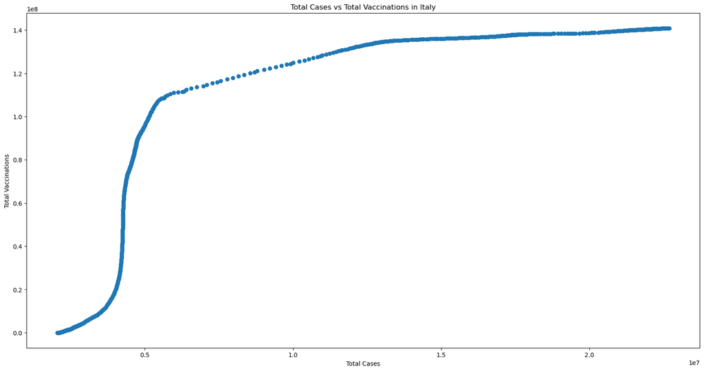

```
           date  new_cases_per_million  new_vaccinations_smoothed_per_million
365  2021-01-30                214.600                                 1302.0
366  2021-01-31                189.888                                 1365.0
367  2021-02-01                133.777                                 1405.0
368  2021-02-02                162.913                                 1424.0
369  2021-02-03                222.517                                 1494.0
..          ...                    ...                                    ...
725  2022-01-25               3566.439                                 9155.0
726  2022-01-26               2885.534                                 8963.0
727  2022-01-27               2634.016                                 8758.0
728  2022-01-28               2436.634                                 8629.0
729  2022-01-29               2319.822                                 8538.0

[365 rows x 3 columns]
```

```
                                       new_cases_per_million  \
new_cases_per_million                               1.000000
new_vaccinations_smoothed_per_million               0.333908

                                       new_vaccinations_smoothed_per_million
new_cases_per_million                                               0.333908
new_vaccinations_smoothed_per_million                               1.000000
```

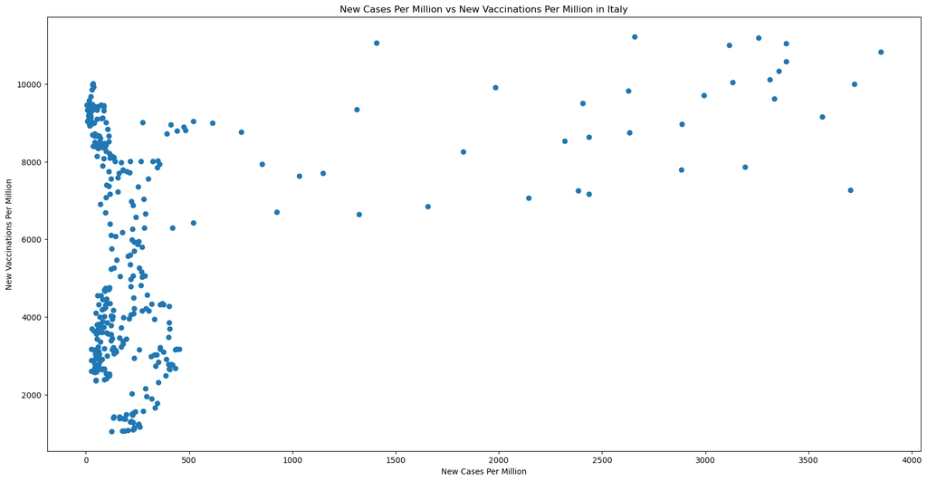

```
           date  total_deaths  total_vaccinations
365  2021-01-30       88279.0           1985160.0
366  2021-01-31       88516.0           2045171.0
367  2021-02-01       88845.0           2131428.0
368  2021-02-02       89344.0           2220078.0
369  2021-02-03       89820.0           2320379.0
..          ...           ...                 ...
725  2022-01-25      144343.0         125522786.0
726  2022-01-26      144770.0         126053739.0
727  2022-01-27      145159.0         126571943.0
728  2022-01-28      145537.0         127104537.0
729  2022-01-29      145914.0         127632878.0

[365 rows x 3 columns]
```

```
                    total_deaths  total_vaccinations
total_deaths            1.000000            0.891763
total_vaccinations      0.891763            1.000000
```

```python
# subquestion 2: is there a correlation between the vacination rate and the number of covid cases?

# create a new dataframe with only total cases and total vaccinations
df_italy_vaccination = df_italy[['total_cases', 'total_vaccinations', 'date']]
print(df_italy_vaccination)

# create a line animation of the total number of cases per date and total vaccinations in Italy date in the same plot
fig = px.line(df_italy_vaccination, x='date', y='total_cases', title='Total Cases in Italy')
fig.add_scatter(x=df_italy_vaccination['date'], y=df_italy_vaccination['total_vaccinations'], mode='lines', name='Total Vaccinations')
fig.show()

# calculate the correlation between total cases and total vaccinations
print(df_italy_vaccination.corr())

# visualize the correlation between total cases and total vaccinations
plt.figure(figsize=(20,10))
plt.scatter(df_italy_vaccination['total_cases'], df_italy_vaccination['total_vaccinations'])
plt.xlabel('Total Cases')
plt.ylabel('Total Vaccinations')
plt.title('Total Cases vs Total Vaccinations in Italy')
plt.show()

# create a new dataframe of the year 2021 of total new cases per million and new vaccinations per million
df_italy_vaccination_2021 = df_italy[['date', 'new_cases_per_million', 'new_vaccinations_smoothed_per_million']][365:365+365]
print(df_italy_vaccination_2021)

# create a line animation of the total number of new cases per million per date and new vaccinations per million in Italy date in the same plot
fig = px.line(df_italy_vaccination_2021, x='date', y='new_cases_per_million', title='New Cases Per Million in Italy')
fig.add_scatter(x=df_italy_vaccination_2021['date'], y=df_italy_vaccination_2021['new_vaccinations_smoothed_per_million'], mode='lines', name='New Vaccinations Per Million')
fig.show()

# calculate the correlation between new cases per million and new vaccinations per million
print(df_italy_vaccination_2021.corr())

# visualize the correlation between new cases per million and new vaccinations per million
plt.figure(figsize=(20,10))
plt.scatter(df_italy_vaccination_2021['new_cases_per_million'], df_italy_vaccination_2021['new_vaccinations_smoothed_per_million'])
plt.xlabel('New Cases Per Million')
plt.ylabel('New Vaccinations Per Million')
plt.title('New Cases Per Million vs New Vaccinations Per Million in Italy')
plt.show()

# create a new dataframe of the year 2021 of the total number of deaths and total vaccinations
df_italy_vaccination_2021 = df_italy[['date', 'total_deaths', 'total_vaccinations']][365:365+365]
print(df_italy_vaccination_2021)

# create a animation of the total number of deaths per date and total vaccinations in Italy date with a slider of the dates
fig = px.line(df_italy_vaccination_2021, x='date', y='total_deaths', title='Total Deaths in Italy')
fig.add_scatter(x=df_italy_vaccination_2021['date'], y=df_italy_vaccination_2021['total_vaccinations'], mode='lines', name='Total Vaccinations')
fig.show()
# add slider
fig.update_layout(xaxis_rangeslider_visible=True)

# calculate the correlation between total deaths and total vaccinations
print(df_italy_vaccination_2021.corr())
```

```
           date  total_cases
152  2020-07-01     240760.0
153  2020-07-02     240961.0
154  2020-07-03     241184.0
155  2020-07-04     241419.0
156  2020-07-05     241611.0
157  2020-07-06     241819.0
158  2020-07-07     241956.0
159  2020-07-08     242149.0
160  2020-07-09     242363.0
161  2020-07-10     242639.0
162  2020-07-11     242827.0
163  2020-07-12     243061.0
164  2020-07-13     243230.0
165  2020-07-14     243344.0
```

[output cut: 18 more lines]

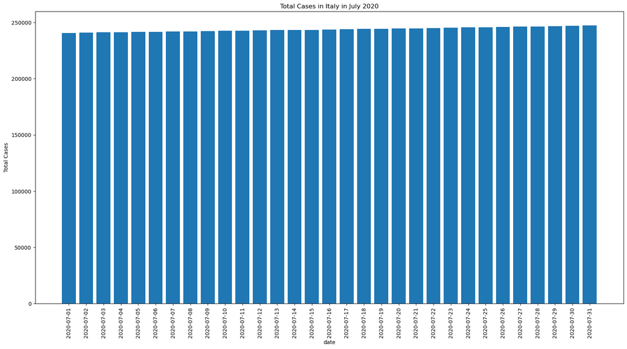

```
           date  total_cases
517  2021-07-01    4260788.0
518  2021-07-02    4261582.0
519  2021-07-03    4262511.0
520  2021-07-04    4263317.0
521  2021-07-05    4263797.0
522  2021-07-06    4264704.0
523  2021-07-07    4265714.0
524  2021-07-08    4267105.0
525  2021-07-09    4268491.0
526  2021-07-10    4269885.0
527  2021-07-11    4271276.0
528  2021-07-12    4272163.0
529  2021-07-13    4273693.0
530  2021-07-14    4275846.0
```

[output cut: 18 more lines]

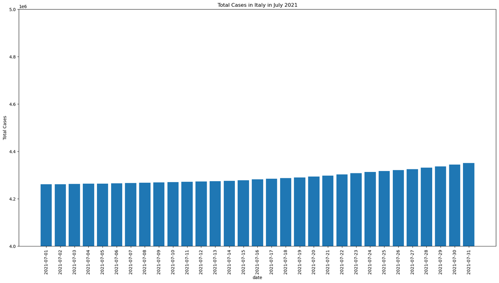

```
Total number of new cases in Italy in July 2020:  6777.0
Total number of new cases in Italy in July 2021:  89240.0
```

```python
# subuestion 3: was there an asending or descending trend in covid cases in Italy in the month July 2020 and July 2021?
# import df_italy.csv and call it df_italy
df_italy = pd.read_csv('df_italy.csv')

# create a new dataframe with only total cases in July 2020 and dates
df_italy_july_2020 = df_italy[['date', 'total_cases']][183-31:183]

# print the new dataframe
print(df_italy_july_2020)

#print size of the dataframe df_italy_july_2020
print(df_italy_july_2020.shape)

# visualize the total number of cases in Italy in July 2020
plt.figure(figsize=(20,10))
plt.bar(df_italy_july_2020['date'], df_italy_july_2020['total_cases'])
plt.xlabel('date')
# in order to show the date in the x-axis, we need to rotate the labels
plt.xticks(rotation=90)
plt.ylabel('Total Cases')
plt.title('Total Cases in Italy in July 2020')
plt.show()

# create a new dataframe with only total cases in July 2021 and dates
df_italy_july_2021 = df_italy[['date', 'total_cases']][548-31:548]

# print the new dataframe
print(df_italy_july_2021)

#print size of the dataframe df_italy_july_2021
print(df_italy_july_2021.shape)

# visualize the total number of cases in Italy in July 2021
plt.figure(figsize=(20,10))
plt.bar(df_italy_july_2021['date'], df_italy_july_2021['total_cases'])
# y axis scale is to big, so make it smaller
plt.ylim(4000000, 5000000)
plt.xlabel('date')
# in order to show the date in the x-axis, we need to rotate the labels
plt.xticks(rotation=90)
plt.ylabel('Total Cases')
plt.title('Total Cases in Italy in July 2021')
plt.show()

#calculate the total number of new cases in July 2020
print('Total number of new cases in Italy in July 2020: ', df_italy_july_2020.iloc[30, 1]-df_italy_july_2020.iloc[0, 1])

#calculate the total number of new cases in July 2021
print('Total number of new cases in Italy in July 2021: ', df_italy_july_2021.iloc[30, 1]-df_italy_july_2021.iloc[0, 1])
```